# Grouping and summarizing using dplyr

## Libraries

```r
library(tidyverse)
```

## Data

We’ll use the `penguins` data and the yeast colony morphology data that Greg introduced in the first part of this lecture.

```r
library(palmerpenguins)

yeast_URL <- "https://github.com/Bio724D/Bio724D_2024_2025/raw/main/data/seg_strain_table.csv"
yeast <- read_csv(yeast_URL)
glimpse(yeast)
```

## Grouping

dplyr’s grouping functions are one of the most powerful features of the tidyverse. Appropriate application of `group_by()` and related functions is a huge time saver in terms of discovering, exploring, and exploiting sub-structure within your data.

### Grouping using `group_by`

The function `group_by` “decorates” a data frame with grouping information:

- `group_by` by itself doesn’t do any further calculations
- Multiple variables can be used in a grouping statement

After grouping, there is no visible restructuring of the data frame:

```r
by_pool <-
  yeast |>
  group_by(Pool)

# Use View() to view the group DF
# use glimpse or str to view the grouped df
```

In this second example, we group by both morphology and genotype:

```r
by_pool_and_genotype <-
  yeast |>
  group_by(Pool, Cyr1.geno)

# as before, use glimpse to take a look at this df
```

### Functions for exploring grouped data frames

Although a grouped data frame doesn’t look different, its has additional information attached to it that affect how it works with group-aware operations. There are a variety of dplyr functions for querying a data frame about it’s grouping structure (if any).

#### `is.grouped_df`

You can check if a data frame is grouped using `is.grouped_df`

```r
is.grouped_df(by_pool)
```

#### `groups`

`groups` returns the variable(s) the data frame is grouped on:

```r
groups(by_pool)
groups(by_pool_and_genotype)
```

#### `group_keys`

`group_keys` returns a data frame describing the groups:

```r
group_keys(by_pool)
group_keys(by_pool_and_genotype)
```

#### `group_size`

`group_size` returns the number of observations in each group:

```r
group_size(by_pool)
group_size(by_pool_and_genotype)
```

### ★ Grouping: Self exploration

Use the help and code exploration to understand what the functions `group_rows`, `group_indices` and `group_split` do.

### Removing grouping information using `ungroup`

Grouping can be removed using the `ungroup` function:

```r
by_pool |>
  ungroup() |>
  is.grouped_df()
```

## Counting observations by group

The function `dplyr::count` when applied to a grouped data frame will return a data frame giving the count of observations per group:

```r
count(by_pool_and_genotype)
```

If counting is all you want to do, then you don’t need to explicitly group before hand as the `count` function takes grouping variables as arguments:

```r
yeast |>
  count(Pool, Cyr1.geno)
```

When generating a table of counts on two or more grouping variables, the output is essentially a contingency table. We can turn this counts data frame into a more conventional contingency table layout using the `xtabs` function from base R:

```r
# NOTE: the underscore "_" in the call to
# xtabs below is a placeholder you can use when
# the value you're passing in a pipe isn't the first
# argument to the function on the right.

yeast |>
  count(Pool, Cyr1.geno) |>
  xtabs(n ~ Pool + Cyr1.geno, data = _)
```

## Summarizing by group

The `summarize` function allows us to create group-wise data summaries. This is a very powerful tool for calculate summary statistics for marginal distributions.

```r
by_pool_and_genotype |>
  summarize(nobs = n(),
            mean_Cyr1.exp = mean(Cyr1.expr, na.rm = TRUE),
            sd_Cyr1.exp = sd(Cyr1.expr, na.rm = TRUE))
```

## Row-wise summaries

`summarize` works across rows, but sometimes you want to make calculations across columns. The `rowwise` function facilitates this:

```r
yeast |>
  rowwise() |>
  mutate(mean.Adhes = mean(c_across(starts_with("Adhes"))),
         mean.CM = mean(c_across(CM.a:CM.c)))

# two different ways to select columns above
# Note that ranges can be fragile when data gets reordered
```

## More complex operations on groups

In addition to `summarize()` and `count()` which are explicitly grouping functions, several of the dplyr functions we have already encountered will taking grouping structure into account.

### `filter` after `group_by`

`filter` can be applied in a group-wise fashion, with the filtering applied separately within each group and those observations passing the criteria returned in a groupd data frame:

Compare the ungrouped result:

```r
penguins |>
  filter(body_mass_g == max(body_mass_g, na.rm = TRUE))
```

to the grouped result:

```r
penguins |>
  group_by(species) |>
  filter(body_mass_g == max(body_mass_g, na.rm = TRUE))
```

### `mutate` after `group_by`

`mutate` is also “group aware”, and will apply it’s calculations in a group-wise manner on a grouped data frame.

The following code calculates the differences between individual penguin body mass and the “grand mean” of body mass (taken across all penguins in the dataset):

```r
penguins |>
  mutate(deviation = body_mass_g - mean(body_mass_g, na.rm = TRUE)) |>
  pull(deviation) |> # pull is a dplyr function similar to $
  head(5)
```

If we apply `group_by()` first, the calculations in `mutate` are applied in a group-wise fashion. In this case, we are computing the the deviation of each penguin from its species mean:

```r
penguins |>
  group_by(species) |>
  mutate(deviation = body_mass_g - mean(body_mass_g, na.rm = TRUE)) |>
  pull(deviation) |>
  head(5)
```

### `slice` after `group_by`

The various dplyr `slice` functions are group aware:

```r
# get the first observation of each species
penguins |>
  group_by(species) |>
  slice(1)
```

```r
# get the smallest penguin(s) by body mass for each species
penguins |>
  group_by(species) |>
  slice_min(body_mass_g)
```

## The .by argument to `summarize`, `filter`, `mutate`, and `slice`

Grouping followed by filtering, mutating, and slicing are common enough operations that recent versions of dplyr have implemented the ability to do grouping operations directly from these functions. This is accomplished by [using the `.by` argument](https://dplyr.tidyverse.org/reference/dplyr_by.html):

```r
penguins |>
  summarize(mean_body_mass = mean(body_mass_g, na.rm = TRUE),
            sd_body_mass = sd(body_mass_g, na.rm = TRUE),
            .by = species)
```

Here’s an example using `slice`:

```r
penguins |>
  drop_na() |>
  slice(2, .by = c(species, sex))
```

Unlike `group_by()` followed by these functions, when the `.by` argument is used an *ungrouped* data frame is always returned. i.e. The grouping only applies within the calling function.

## Applying functions by group using `group_map` and `group_modify`

Sometimes we want to do grouped operations that are relatively complex, such as fitting a linear regression to sub-groups within the data.

This is relatively easy to generate a plot such as this in ggplot.

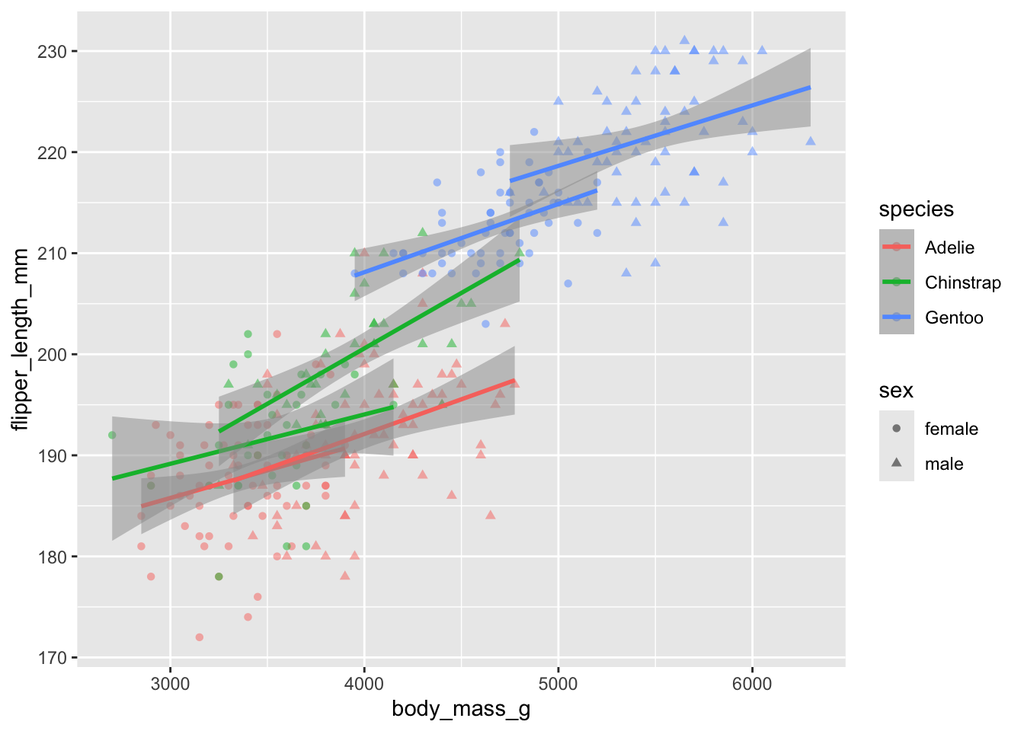

```r
penguins |>
  filter(!is.na(sex)) |>
  ggplot(aes(x = body_mass_g,
             y = flipper_length_mm,
             color = species,
             shape = sex)) +
  geom_point(alpha = 0.5) +
  geom_smooth(method = lm, alpha=0.5)
```

ggplot is clearly fitting 6 different linear models to the grouped data (sex and species) “behind the scenes”. How could we do these calculations succinctly and efficiently ourselves? The function `group_map` and `group_modify` are useful to solve this problem.

```r
penguins_by_species_sex <-
  penguins |>
  filter(!is.na(sex)) |>
  group_by(species, sex)

lm_by_species_sex <-
  penguins_by_species_sex |>
  group_map(~lm(flipper_length_mm ~ body_mass_g, data = .x))

lm_by_species_sex
```

`group_modify` is similar to `group_map` but requires that the output of the function is a data frame. Since the `lm` function does not return it’s results in the form of a data frame, we turn to a package called [`broom`](https://broom.tidymodels.org/index.html) which is a library that turns model fit output into data frames for us. Broom has three basic functions: `tidy`, `glance`, and `augment`. Here we use the `tidy` function to report information about the coefficients of the linear models that are fit to each group in the data:

```r
library(broom)

lm_by_species_sex_df <-
  penguins_by_species_sex |>
  group_modify(~ broom::tidy(lm(flipper_length_mm ~ body_mass_g, data = .x)))

lm_by_species_sex_df
```

## Extended example: ANOVA visualized

### ANOVA, key idea

Recall that the key idea behind Analysis of Variance (ANOVA) is that:

- If the observations in each group are drawn from populations with equal means (and variances) then the variation *between* group means should be similar to the inter-individual variation *within groups*.
- The test statistic used in ANOVA is designated $F$, and is based on the ratio of two measures of variance, the “group mean square deviation” ($\text{MS}_\text{groups}$; measures between group variance) and the “error mean square deviation” ($\text{MS}_\text{error}$; measures within group variance):

$$F = \frac{\text{MS}_\text{group}}{\text{MS}_\text{error}}$$

- Under the null hypothesis, the between group and within group variances are similar and thus the $F$ statistic should be approximately 1.
- Large values of the $F$-statistic means that the between group variance exceeds the within group variance, indicating that at least one of the means is different from the others

### Partioning of sum of squares

Another way to think about ANOVA is as a “partitioning of variance”. The total variance among all the individuals across groups can be decomposed into:

1. variance of the group means around the “grand mean”
2. variance of individuals around the group means.

However, rather than using variance we use sums of square deviations around the respective means (usually shortened to “sums of squares”).

```r
clean_penguins <-
  penguins |>
  filter(!is.na(sex))

# for completeness we show one way to calculate the grand mean (in tibble form)
penguins_grand <-
  clean_penguins |>
  summarize(mean_bodymass = mean(body_mass_g))

# group means
penguins_group <-
  clean_penguins |>
  group_by(species) |>
  summarize(mean_bodymass = mean(body_mass_g))

# deviations of each penguin around grand mean and group means
individual_deviates <-
  clean_penguins |>
  select(species, body_mass_g) |>
  mutate(grand_deviates = body_mass_g - mean(body_mass_g)) |>
  group_by(species) |>
  mutate(group_deviates = body_mass_g - mean(body_mass_g))

# deviations of group means around grand mean
group_deviates <-
  penguins_group |>
  mutate(deviates = mean_bodymass - mean(clean_penguins$body_mass_g))
```

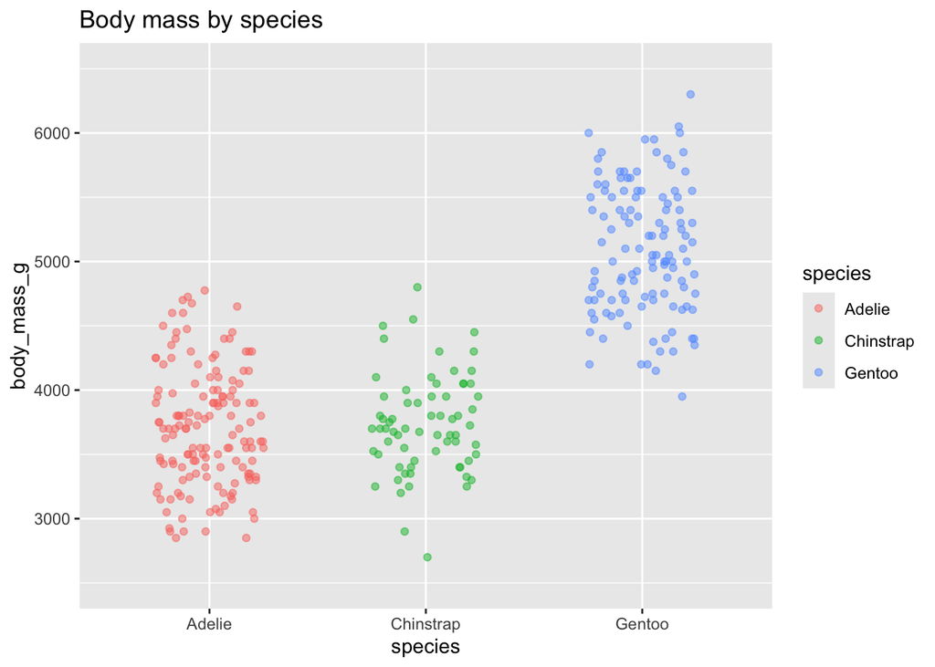

```r
jitterpos <- position_jitter(width=0.25, height=0,
                             seed = 20240917)

clean_penguins |>
  ggplot(aes(x = species, y = body_mass_g,
             color = species)) +
  geom_point(position = jitterpos, alpha=0.5) +
  ylim(2500,6500) +
  labs(title = "Body mass by species")
```

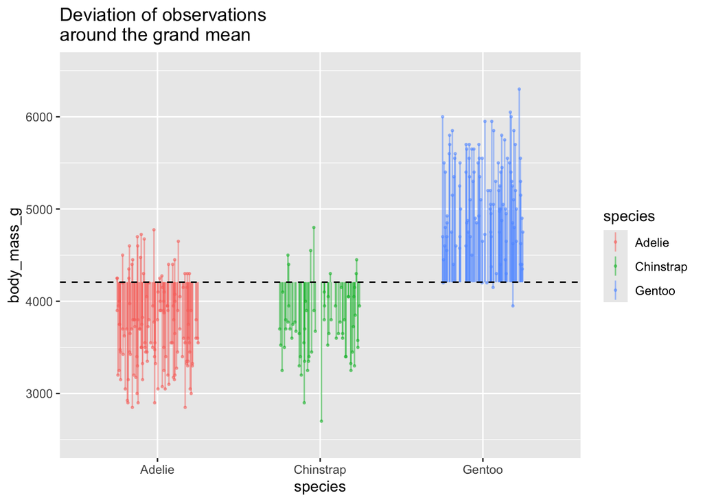

```r
p_total <-
  clean_penguins |>
  ggplot(aes(x = species,
             y = body_mass_g,
             color = species)) +
  geom_point(position = jitterpos,
             alpha=0.5,
             size=0.5) +
  geom_linerange(aes(ymin = penguins_grand$mean_bodymass,
                     ymax = body_mass_g),
                 position = jitterpos,
                 alpha=0.5) +
  geom_hline(yintercept = penguins_grand$mean_bodymass, linetype='dashed') +
  ylim(2500,6500) +
  labs(title = "Deviation of observations\naround the grand mean")

p_total
```

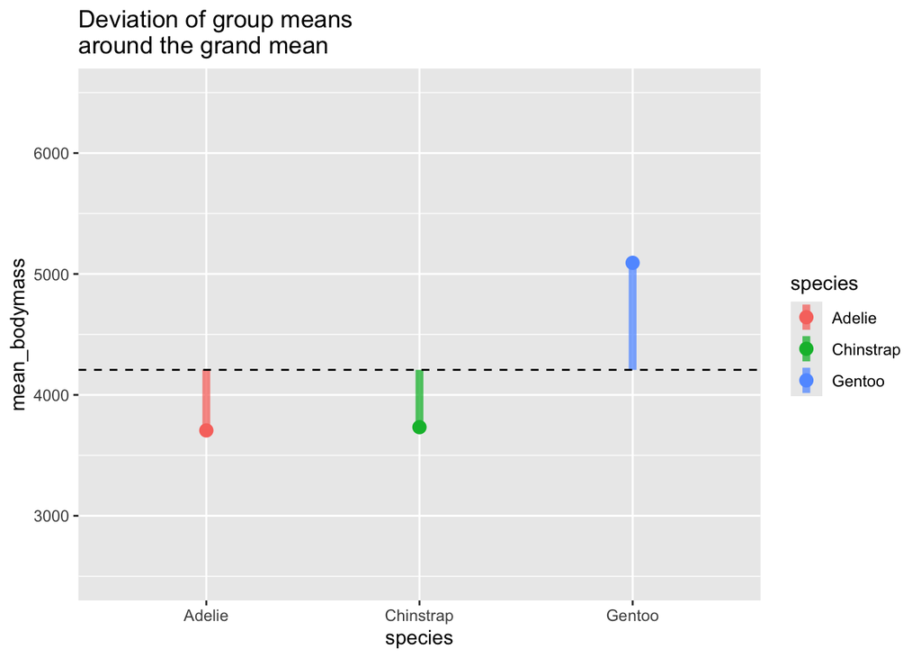

```r
p_between <-
  penguins_group |>
  ggplot(aes(x = species,
             y = mean_bodymass,
             color = species)) +
  geom_point(size = 3) +
  geom_linerange(aes(ymin = penguins_grand$mean_bodymass,
                     ymax = mean_bodymass),
                 alpha=0.75, size=2) +
  geom_hline(yintercept = penguins_grand$mean_bodymass,
             linetype='dashed') +
  ylim(2500,6500) +
  labs(title = "Deviation of group means\naround the grand mean")

p_between
```

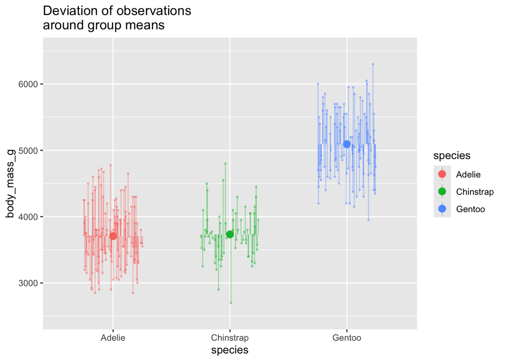

```r
p_within <-
  clean_penguins |>
  group_by(species) |>
  mutate(group_mean_bodymass = mean(body_mass_g, na.rm = TRUE)) |>
  ggplot(aes(x = species,
             y = body_mass_g,
             color = species)) +
  geom_point(position = jitterpos,
             alpha=0.35,
             size=0.5) +
  geom_linerange(aes(ymin = group_mean_bodymass,
                     ymax = body_mass_g),
                 position = jitterpos,
                 alpha=0.35) +
  geom_point(data = penguins_group,
             aes(x = species, y = mean_bodymass),
             size = 3) +
  ylim(2500,6500) +
  labs(title = "Deviation of observations\naround group means")


p_within
```

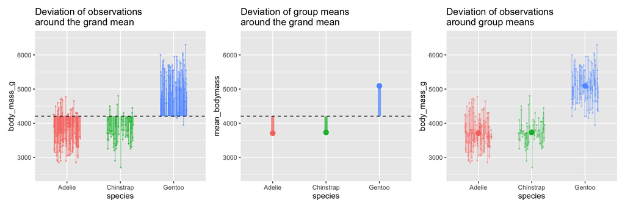

```r
library(patchwork)

combined <-
  (p_total + theme(legend.position = "none")) +
  (p_between + theme(legend.position = "none")) +
  (p_within + theme(legend.position = "none"))

combined
```